# Chapter 7: Model Assumptions and Categorical Inference

2026-02-25

# 1 Assumption Checking

Parametric tests (t-tests, ANOVA, regression) rest on assumptions about the data. Violating them can produce misleading p-values and incorrect conclusions. Always check assumptions **before** running the test.

## 1.1 The Three Core Assumptions

| Assumption | What it requires | What happens if violated |
| --- | --- | --- |
| **Normality** | Data (or residuals) follow a Normal distribution | t-tests lose accuracy; p-values become unreliable for small $n$ |
| **Equal variances** | Group variances $\sigma_1^2 \approx \sigma_2^2$ in two-sample tests | Inflated Type I error with Student’s t-test |
| **Independence** | Observations do not influence each other | Standard errors are underestimated; spurious significance |

## 1.2 Normality

Normality is most critical when $n$ is small. For large $n$, the **Central Limit Theorem** means the sampling distribution of $\bar{X}$ is approximately Normal even if the raw data is not.

Ways to check normality:

1. **Histogram** — does it look bell-shaped?
2. **Q-Q plot** — points should fall along the diagonal reference line.
3. **Shapiro-Wilk test** — formal test; $p > 0.05$ → no strong evidence against normality.

## 1.3 Equal Variances

The assumption of **homoscedasticity** (equal variances) matters for two-sample t-tests and ANOVA.

Ways to check:

1. **Side-by-side boxplots** — boxes of similar height suggest similar spread.
2. **Levene’s test / `var.test()`** — formal test; $p > 0.05$ → variances are not significantly different.

> **Practical note:** R’s default `t.test()` uses **Welch’s correction** (`var.equal = FALSE`), which is robust to unequal variances. Only switch to `var.equal = TRUE` after confirming equal variances.

## 1.4 Independence

Independence is usually ensured by **study design**, not statistical testing:

- Use **random sampling** or **random assignment**.
- Avoid measuring the same subject multiple times without accounting for it (use paired tests or mixed models).
- Be wary of **clustered data** (e.g., students within classrooms) where observations within a group are correlated.

# 2 Chi-Squared Methods

When data is **categorical** (counts, frequencies, labels), we move away from means and into the world of the **chi-squared** ($\chi^2$) distribution.

## 2.1 Goodness-of-Fit Test

Tests whether an observed frequency distribution matches a specified (theoretical) distribution.

$$\chi^2 = \sum_{i=1}^{k} \frac{(O_i -
E_i)^2}{E_i}$$

where $O_i$ = observed count, $E_i$ = expected count in category $i$, and df $= k - 1$.

**Decision rule:** Reject $H_0$ if $\chi^2_{\text{stat}} > \chi^2_{\text{critical}}$ (or if $p < \alpha$).

**Example:** A die is rolled 60 times. We expect 10 of each face. Do the observed counts match?

```r
set.seed(42)

# Simulate 60 die rolls
observed <- table(sample(1:6, size = 60, replace = TRUE))
expected <- rep(10, 6)   # equal probability

# Chi-squared goodness-of-fit test
chi_gof <- chisq.test(observed, p = rep(1/6, 6))
chi_gof
```

```
#>
#>  Chi-squared test for given probabilities
#>
#> data:  observed
#> X-squared = 7.2, df = 5, p-value = 0.2062
```

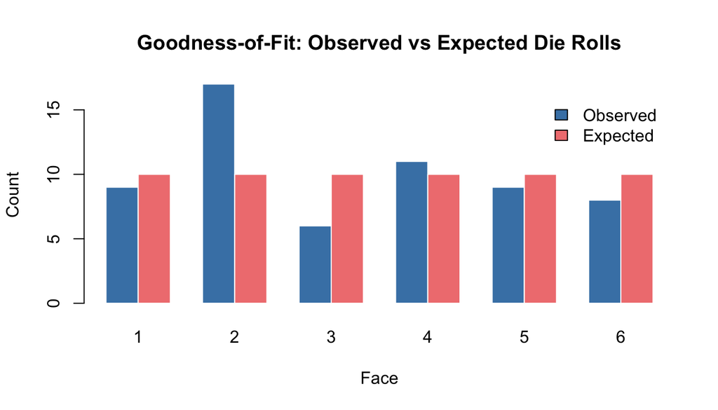

```r
# Visualise observed vs expected
barplot(rbind(as.numeric(observed), expected),
        beside   = TRUE,
        names.arg = 1:6,
        col      = c("steelblue", "lightcoral"),
        border   = "white",
        main     = "Goodness-of-Fit: Observed vs Expected Die Rolls",
        xlab     = "Face",
        ylab     = "Count",
        legend.text = c("Observed", "Expected"),
        args.legend = list(bty = "n"))
```

## 2.2 Test of Independence

Tests whether two categorical variables are **associated** or **independent** using a contingency table.

$$\chi^2 = \sum_{i}\sum_{j} \frac{(O_{ij}
- E_{ij})^2}{E_{ij}}, \quad E_{ij} = \frac{(\text{row
total}_i)(\text{col total}_j)}{n}$$

df $= (\text{rows} - 1) \times (\text{columns} - 1)$

**Example:** Is there a relationship between gender and product preference?

```r
# 2×2 contingency table: Gender × Preference
survey_table <- matrix(c(30, 20,
                         25, 25),
                       nrow = 2, byrow = TRUE,
                       dimnames = list(Gender     = c("Male", "Female"),
                                       Preference = c("Product A", "Product B")))

survey_table
```

```
#>         Preference
#> Gender   Product A Product B
#>   Male          30        20
#>   Female        25        25
```

```r
# Chi-squared test of independence
chi_ind <- chisq.test(survey_table)
chi_ind
```

```
#>
#>  Pearson's Chi-squared test with Yates' continuity correction
#>
#> data:  survey_table
#> X-squared = 0.64646, df = 1, p-value = 0.4214
```

```r
# View expected counts under H0 (independence)
chi_ind$expected
```

```
#>         Preference
#> Gender   Product A Product B
#>   Male        27.5      22.5
#>   Female      27.5      22.5
```

> **Assumption:** All expected cell counts should be $\geq 5$. If not, use **Fisher’s Exact Test** (`fisher.test()`) instead.

# 3 Mathematical Foundations

## 3.1 The Chi-Squared Distribution

The $\chi^2$ distribution arises when you **square and sum** independent standard Normal random variables:

$$\chi^2_k = \sum_{i=1}^{k} Z_i^2, \quad
Z_i \sim \mathcal{N}(0,1)$$

Properties:

| Property | Detail |
| --- | --- |
| Shape | Right-skewed; approaches Normal as df increases |
| Support | $[0, \infty)$ — always non-negative (sum of squares) |
| Mean | $k$ (degrees of freedom) |
| Variance | $2k$ |

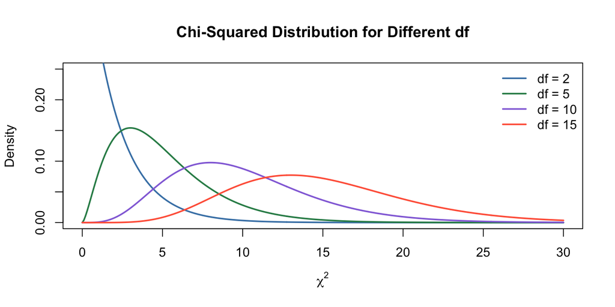

```r
x <- seq(0, 30, length.out = 300)

plot(NULL, xlim = c(0, 30), ylim = c(0, 0.25),
     main = "Chi-Squared Distribution for Different df",
     xlab = expression(chi^2), ylab = "Density")

dfs    <- c(2, 5, 10, 15)
colours <- c("steelblue", "seagreen", "mediumpurple", "tomato")

for (i in seq_along(dfs)) {
  lines(x, dchisq(x, df = dfs[i]),
        col = colours[i], lwd = 2)
}

legend("topright",
       legend = paste0("df = ", dfs),
       col    = colours,
       lwd    = 2, bty = "n")
```

## 3.2 Degrees of Freedom

**Degrees of freedom (df)** control the shape of the $\chi^2$ distribution and depend on the test:

| Test | df formula | Intuition |
| --- | --- | --- |
| Goodness-of-fit | $k - 1$ | $k$ categories; 1 constraint (counts sum to $n$) |
| Test of independence | $(r-1)(c-1)$ | $r$ rows, $c$ columns; row and column totals are fixed |

# 4 R Coverage

## 4.1 `shapiro.test()` — Normality Check

```r
sample_data <- c(12, 15, 14, 10, 13, 16, 14, 11, 15, 13)

shapiro.test(sample_data)
```

```
#>
#>  Shapiro-Wilk normality test
#>
#> data:  sample_data
#> W = 0.96446, p-value = 0.8353
```

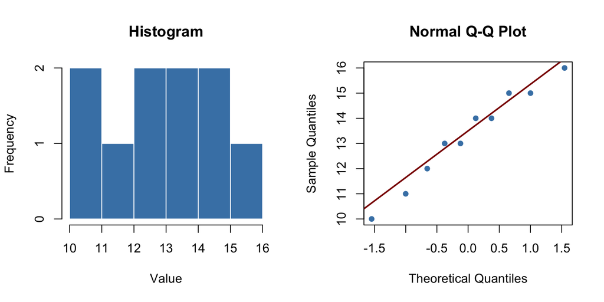

```r
par(mfrow = c(1, 2))

# Histogram
hist(sample_data,
     col    = "steelblue",
     border = "white",
     main   = "Histogram",
     xlab   = "Value")

# Q-Q plot: points near the line → approximately Normal
qqnorm(sample_data, main = "Normal Q-Q Plot",
       col = "steelblue", pch = 16)
qqline(sample_data, col = "darkred", lwd = 2)
```

```r
par(mfrow = c(1, 1))
```

**Interpreting `shapiro.test()`:**

| p-value | Conclusion |
| --- | --- |
| $> 0.05$ | No significant departure from normality |
| $\leq 0.05$ | Evidence that data is **not** normally distributed |

> ⚠️ With large samples, Shapiro-Wilk detects trivially small deviations. Always combine with the Q-Q plot for a fuller picture.

## 4.2 `var.test()` — Equal Variances Check

```r
group_A <- c(10, 12, 11, 13, 12)
group_B <- c(14, 18, 15, 17, 16)

var.test(group_A, group_B)
```

```
#>
#>  F test to compare two variances
#>
#> data:  group_A and group_B
#> F = 0.52, num df = 4, denom df = 4, p-value = 0.5421
#> alternative hypothesis: true ratio of variances is not equal to 1
#> 95 percent confidence interval:
#>  0.05414112 4.99435554
#> sample estimates:
#> ratio of variances
#>               0.52
```

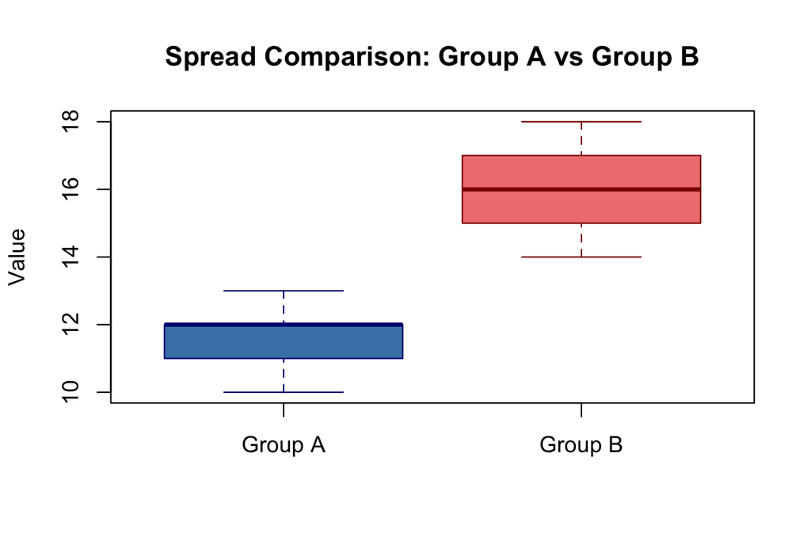

```r
boxplot(group_A, group_B,
        names  = c("Group A", "Group B"),
        col    = c("steelblue", "lightcoral"),
        border = c("navy", "darkred"),
        main   = "Spread Comparison: Group A vs Group B",
        ylab   = "Value")
```

**Interpreting `var.test()`:**

| p-value | Conclusion |
| --- | --- |
| $> 0.05$ | Variances are not significantly different → `var.equal = TRUE` is defensible |
| $\leq 0.05$ | Variances differ significantly → use Welch’s t-test (default) |

## 4.3 `chisq.test()` — Categorical Inference

```r
# --- Goodness-of-fit ---
observed_counts <- c(18, 22, 20)          # 3 categories
chisq.test(observed_counts,
           p = c(1/3, 1/3, 1/3))         # expected: equal proportions
```

```
#>
#>  Chi-squared test for given probabilities
#>
#> data:  observed_counts
#> X-squared = 0.4, df = 2, p-value = 0.8187
```

```r
# --- Test of independence ---
data_table <- matrix(c(30, 20, 25, 25),
                     nrow = 2, byrow = TRUE)
chisq.test(data_table)
```

```
#>
#>  Pearson's Chi-squared test with Yates' continuity correction
#>
#> data:  data_table
#> X-squared = 0.64646, df = 1, p-value = 0.4214
```

### 4.3.1 What `chisq.test()` returns

| Output element | Meaning |
| --- | --- |
| `$statistic` | Computed $\chi^2$ value |
| `$p.value` | Probability of result under $H_0$ |
| `$expected` | Expected counts under $H_0$ |
| `$residuals` | $(O-E)/\sqrt{E}$ — large values indicate which cells drive the result |

```r
# Inspect residuals to see which cells contribute most
chi_ind$residuals
```

```
#>         Preference
#> Gender    Product A  Product B
#>   Male    0.4767313 -0.5270463
#>   Female -0.4767313  0.5270463
```

# 5 Choosing the Right Test: Decision Guide

Quick-reference test selection guide

[output not shown]

# 6 Chapter Summary

| Concept | Key Takeaway |
| --- | --- |
| Normality assumption | Check with Shapiro-Wilk + Q-Q plot; CLT helps for large $n$ |
| Equal variances | Check with `var.test()`; use Welch’s t-test when in doubt |
| Independence | Ensured by study design (random sampling / assignment) |
| Goodness-of-fit | $\chi^2$ compares observed vs theoretical distribution; df $= k-1$ |
| Test of independence | $\chi^2$ tests association in a contingency table; df $= (r-1)(c-1)$ |
| Chi-squared distribution | Right-skewed; sum of squared Normals; mean = df |
| Expected counts | Must be $\geq 5$ per cell; otherwise use Fisher’s Exact Test |
| R: `shapiro.test()` | $p > 0.05$ → normality is plausible |
| R: `var.test()` | $p > 0.05$ → equal variances are plausible |
| R: `chisq.test()` | Works for both goodness-of-fit and independence |
| `$residuals` | Pinpoints which cells drive a significant $\chi^2$ result |